# PyData London News April 2016

## Wifi: GST-Man, pw: kumquat05

```python
Image(filename="images/pydata_logo.png", width=600)
```

[output not shown]

# Laptop Theft

- A laptop was stolen at the iOS Meetup a couple weeks ago
- Please be careful when we are in the pub afterwards!

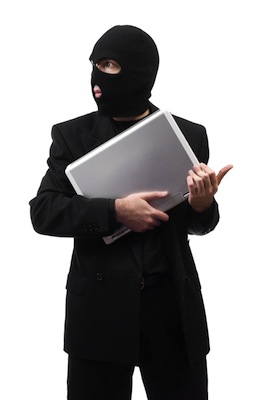

```python
Image('images/laptopthief.jpg')
```

# PyData London Conf Update

- Most of the tickets are sold. ~200 of 330 have been sold.
- Schedule is live, http://pydata.org/london2016/schedule.
- 4 tracks! Including an un-conference and three keynotes!
- Still room for sponsors!

[figure not shown]

```python
Image('images/pydatalondon_conf.png')
```

# Video sponsor

- Sponsoring the recording and post-processing of the videos
- An advertising frame in every video
- Circa £12,000

```python
YouTubeVideo('https://www.youtube.com/watch?v=aGvhgfmKHOM&list=PLGVZCDnMOq0pL4tUzOF0qrUGt6eXgJmwc', width=800)
```

[video not shown]

# Photography sponsor

- Sponsoring a professional photographer to take pictures
- "Supporting" level sponsorship — logo on the website, sponsor tweets and a conference pass
- Anything goes! Except watermarks.
- Circa £1,000

```python
IFrame(src='http://pydata.org/london2016/static/images/banner-london2016.jpg', width=966, height=373)
```

[interactive chart not shown]

# Drinks sponsor

- Sponsor the after-party (does not oblige a free bar)
- Logo on the site and a opportunity to stand up and give a speech at the after party
- Circa £2,000, We Are Wizards are looking to part sponsor

[figure not shown]

```python
Image('images/party.jpg')
```

# Badge and Lanyard sponsors

- Sponsor the provision of badges and lanyards
- Your company name/logo splashed all over the badges and lanyards
- Circa £1000 each

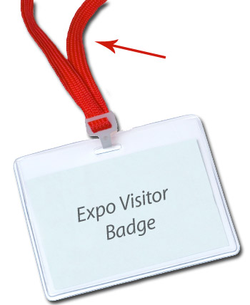

```python
Image('images/lanyard.jpg')
```

# 3000 members! Where does that put us?

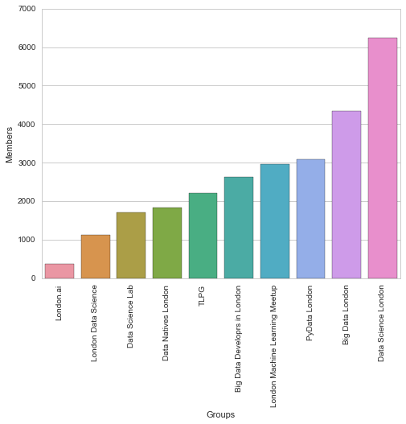

```python
%matplotlib inline
import numpy as np
import seaborn as sns
import matplotlib.pyplot as plt
import pandas as pd
sns.set_style("whitegrid")

f, ax = plt.subplots(1, 1, figsize=(8, 6))

data = {
    'London.ai': 364,
    'London Data Science': 1125,
    'Data Science Lab': 1713,
    'Data Natives London': 1837,
    'TLPG': 2203,
    'Big Data Developrs in London': 2630,
    'London Machine Learning Meetup': 2969,
    'PyData London': 3075,
    'Big Data London': 4344,
    'Data Science London': 6241,
}

for tick in ax.get_xticklabels():
    tick.set_rotation(90)

df = pd.DataFrame({'Members': list(data.values())}, index=data.keys())
df = df.sort_values('Members').transpose()

sns.barplot(data=df)
ax.set_ylabel('Members')
ax.set_xlabel('Groups')
```

# POTM - Glue Explore related datasets

- Linked Graphics
- Select subsets of a section of graphics

```python
IFrame('http://www.glueviz.org/en/stable/', width=1024, height=600)
```

[interactive chart not shown]